# Hotel Booking Analysis

Maftei Alexandru, Vasile Catalina

# Introduction

The dataset contains information on bookings in two types of hotels, both located in Portugal,a resort hotel and a city hotel. Each observation represents a hotel reservation. The data set includes reservations between July 1, 2015 and August 31, 2017, including those canceled. Because it is the actual data of the hotel, all information regarding the identification of the hotel or the client has been deleted. Due to the lack of real business data for scientific and educational purposes, these data sets can play an important role for research and education in revenue management, machine learning or data mining, as well as in other fields.

Every year, more than 140 million bookings were made on the Internet and hotel booking cancellations is a growing problem. An analysis of the last 5 years showed that the cancellation rate on booking has reached almost 40% and this trend produces a very negative impact on hotels revenue and distribution management strategies.

So, it is useful to try to understand and even predict which guests are more likely to cancel their bookings by getting insights from the data set and discovering which features have contributed more to cancellations.

# The dataset

- hotel : resort or city
- is_canceled: canceled=1, not canceled=0
- arrival_date_year
- arrival_date_month
- arrival_date_month : between 1 and 53
- arrival_date_day_of_month
- stays_in_weekend_nights
- stays_in_week_nights
- adults
- children
- babies
- meal: undefined(no package), BB, HB, FB
- country
- market_segment : TA=travel agents, TO=tour operators
- distribution_channel : TA or TO
- is_repeated_guest: yes=1, no=0
- previous_cancellations
- previous_bookings_not_canceled
- reserved_room_type
- assigned_room_type
- booking_changes
- deposit_type: no deposit, non refund or refundable
- agent
- company
- day_in_waiting_list
- customer_type
- adr (average daily rate) =sum of all transactions/no of nights
- required_car_parking_spaces
- total_of_special_requests
- reservation_status: canceled, check-out, no-show
- reservation_status_date

# Preparation of the data set

```
## [1] 4
```

```
## [1] 0
```

```
## 'data.frame':    119390 obs. of  32 variables:
##  $ hotel                         : Factor w/ 2 levels "City Hotel","Resort Hotel": 2 2 2 2 2 2 2 2 2 2 ...
##  $ is_canceled                   : int  0 0 0 0 0 0 0 0 1 1 ...
##  $ lead_time                     : int  342 737 7 13 14 14 0 9 85 75 ...
##  $ arrival_date_year             : int  2015 2015 2015 2015 2015 2015 2015 2015 2015 2015 ...
##  $ arrival_date_month            : Factor w/ 12 levels "April","August",..: 6 6 6 6 6 6 6 6 6 6 ...
##  $ arrival_date_week_number      : int  27 27 27 27 27 27 27 27 27 27 ...
##  $ arrival_date_day_of_month     : int  1 1 1 1 1 1 1 1 1 1 ...
##  $ stays_in_weekend_nights       : int  0 0 0 0 0 0 0 0 0 0 ...
##  $ stays_in_week_nights          : int  0 0 1 1 2 2 2 2 3 3 ...
##  $ adults                        : int  2 2 1 1 2 2 2 2 2 2 ...
##  $ children                      : int  0 0 0 0 0 0 0 0 0 0 ...
##  $ babies                        : int  0 0 0 0 0 0 0 0 0 0 ...
##  $ meal                          : Factor w/ 5 levels "BB","FB","HB",..: 1 1 1 1 1 1 1 2 1 3 ...
##  $ country                       : Factor w/ 178 levels "ABW","AGO","AIA",..: 137 137 60 60 60 60 137 137 137 137 ...
```

[output cut: 18 more lines]

# Exploratory Data Analysis

- perform initial investigations on data in order to discover patterns, anomalies with the help of summary statistics and graphical representations

We will try to answer to questions such as:

- Which month is the most occupied?
- Which month has the greates number of canceled bookings?
- Which hotel has a greater number of cancelations?
- Has the deposit type any effect on the cancelations?
- From which country most tourists come?
- Which is the most booked accommodation type?
- How does the ADR vary over year?

We will also try to find different relationships between the attributes.

# Graphics

```
##
##  C:\Users\catal\AppData\Local\Temp\Rtmpi8zGeU\downloaded_packages
```

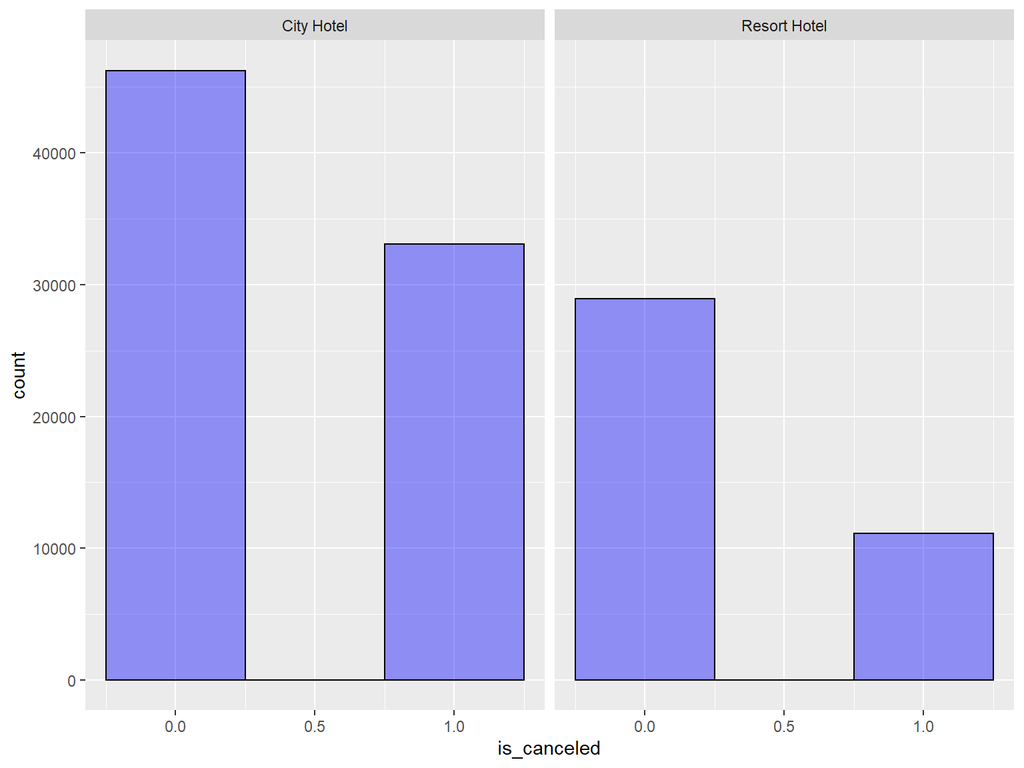

Most of the cancellations are made at city hotels.

```
##
##  C:\Users\catal\AppData\Local\Temp\Rtmpi8zGeU\downloaded_packages
```

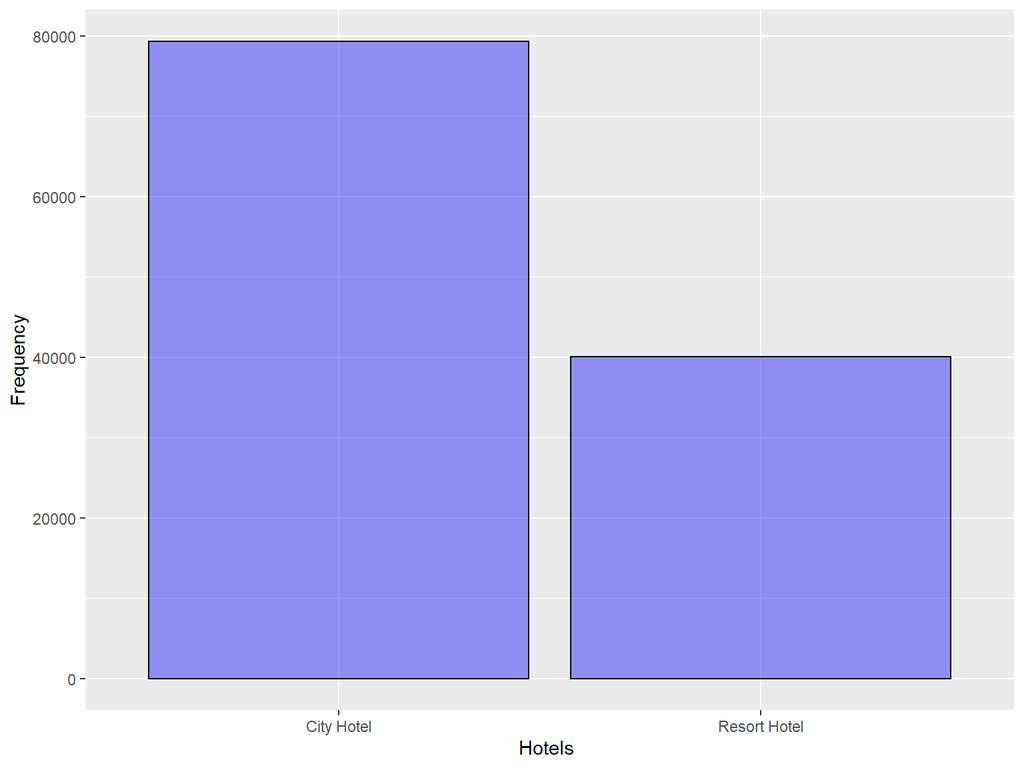

However, clients still prefer city hotels instead of resorts.

```
##
##   City Hotel Resort Hotel
##        79330        40060
```

```
##
##     City Hotel Resort Hotel
##   0      46228        28938
##   1      33102        11122
```

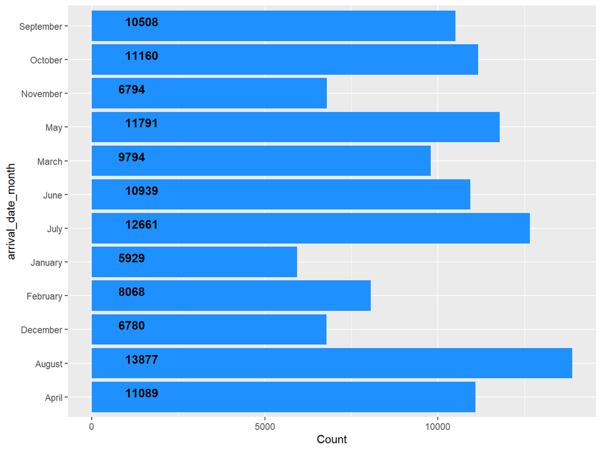

The most popular month is august, followed by july, and the least popular for travelling is january.

```
## # A tibble: 12 x 2
##    `mydataset$arrival_date_month` `length(is_canceled)`
##    <fct>                                          <int>
##  1 April                                          11089
##  2 August                                         13877
##  3 December                                        6780
##  4 February                                        8068
##  5 January                                         5929
##  6 July                                           12661
##  7 June                                           10939
##  8 March                                           9794
##  9 May                                            11791
## 10 November                                        6794
## 11 October                                        11160
## 12 September                                      10508
```

July and august are also the months with the greatest number of cancellations.

```
## # A tibble: 14 x 2
##    `mydataset$adults` `length(is_canceled)`
##                 <int>                 <int>
##  1                  0                   403
##  2                  1                 23027
##  3                  2                 89680
##  4                  3                  6202
##  5                  4                    62
##  6                  5                     2
##  7                  6                     1
##  8                 10                     1
##  9                 20                     2
## 10                 26                     5
## 11                 27                     2
## 12                 40                     1
## 13                 50                     1
## 14                 55                     1
```

[figure not shown]

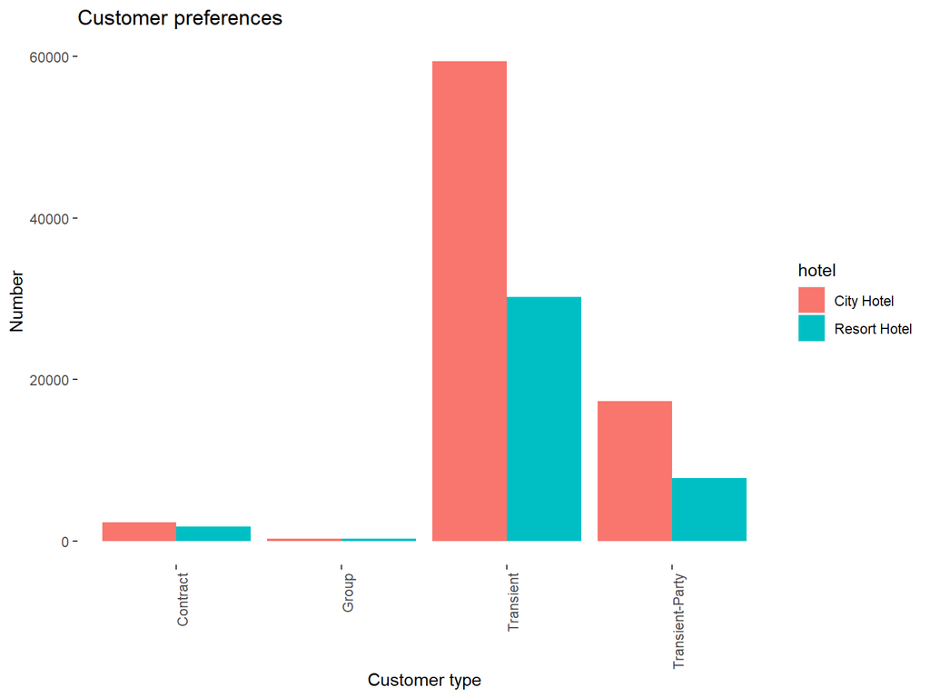

```
## # A tibble: 8 x 2
##   `mydataset$market_segment` `length(is_canceled)`
##   <fct>                                      <int>
## 1 Aviation                                     237
## 2 Complementary                                743
## 3 Corporate                                   5295
## 4 Direct                                     12606
## 5 Groups                                     19811
## 6 Offline TA/TO                              24219
## 7 Online TA                                  56477
## 8 Undefined                                      2
```

The online segment has the greatest number of cancellations.

```
## # A tibble: 10 x 2
##    `mydataset$reserved_room_type` `length(is_canceled)`
##    <fct>                                          <int>
##  1 A                                              85994
##  2 B                                               1118
##  3 C                                                932
##  4 D                                              19201
##  5 E                                               6535
##  6 F                                               2897
##  7 G                                               2094
##  8 H                                                601
##  9 L                                                  6
## 10 P                                                 12
```

Room of type A has the greatest number of cancellations.

```
## PRT    0.406986
## GBR    0.101591
## FRA    0.087235
## ESP    0.071765
## DEU    0.061035
## Name: country, dtype: float64
```

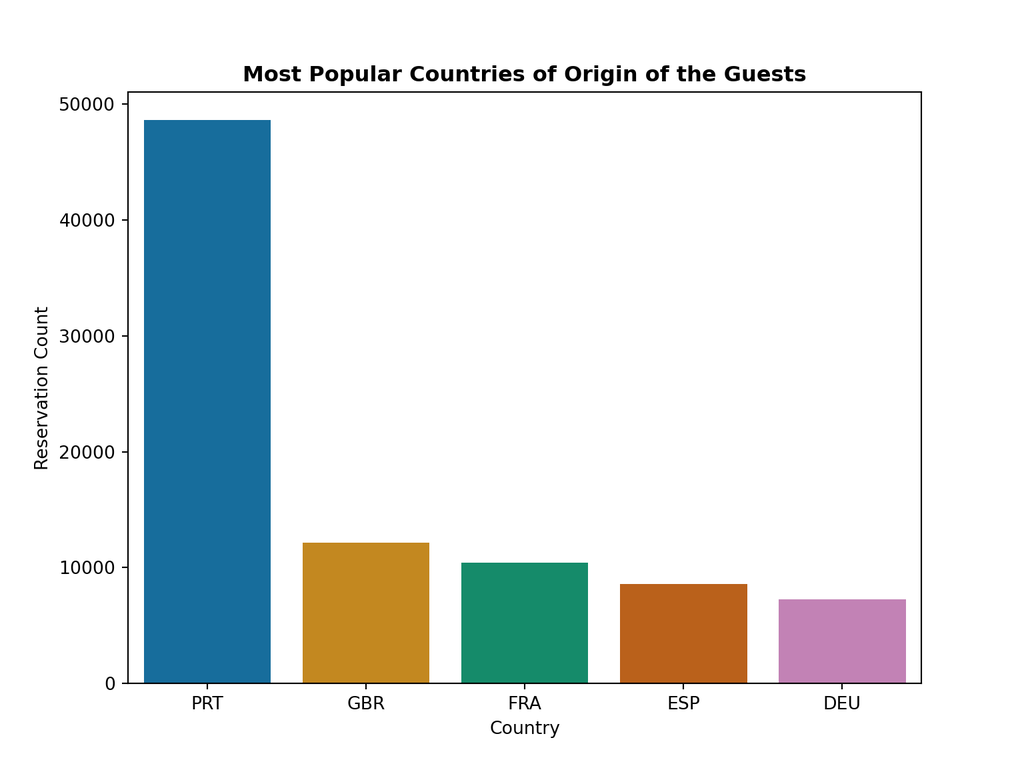

People from almost the entire world choose to spend their holiday in these two hotels. The majority is of course, from Portugal, and also from european countries, such as Great Britain and France.

```
## August       0.116233
## July         0.106047
## May          0.098760
## October      0.093475
## April        0.092880
## June         0.091624
## September    0.088014
## March        0.082034
## February     0.067577
## November     0.056906
## December     0.056789
## January      0.049661
## Name: arrival_date_month, dtype: float64
```

```
## (array([ 0,  1,  2,  3,  4,  5,  6,  7,  8,  9, 10, 11]), <a list of 12 Text major ticklabel objects>)
```

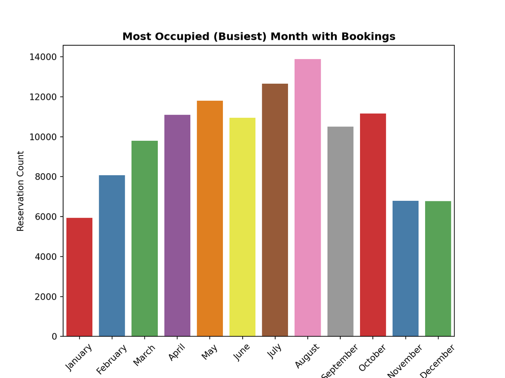

August is the month with the highest number of bookings, followed by July, while January is the most unoccupied month.

```
## 0    0.629584
## 1    0.370416
## Name: is_canceled, dtype: float64
```

[output not shown]

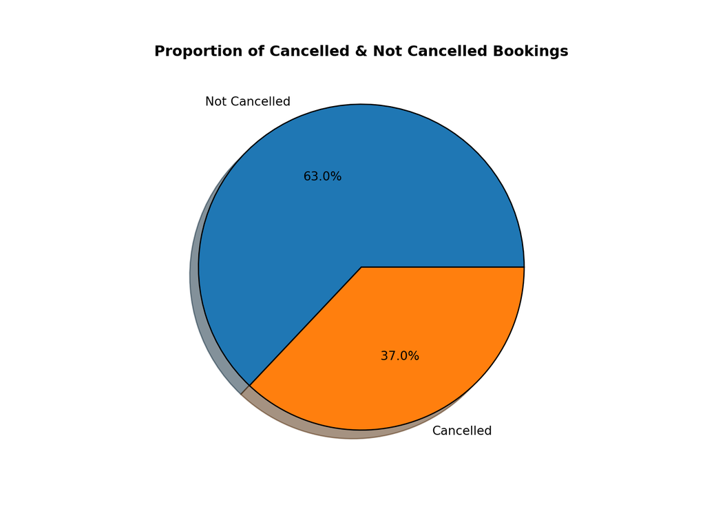

This piechart shows the proportion of cancelled and not cancelled bookings. 37% of the bookings were cancelled, which is a high percentage and which suggests that some measures should be taken.

```
## Online TA        0.473046
## Offline TA/TO    0.202856
## Groups           0.165935
## Direct           0.105587
## Corporate        0.044350
## Complementary    0.006223
## Aviation         0.001985
## Undefined        0.000017
## Name: market_segment, dtype: float64
```

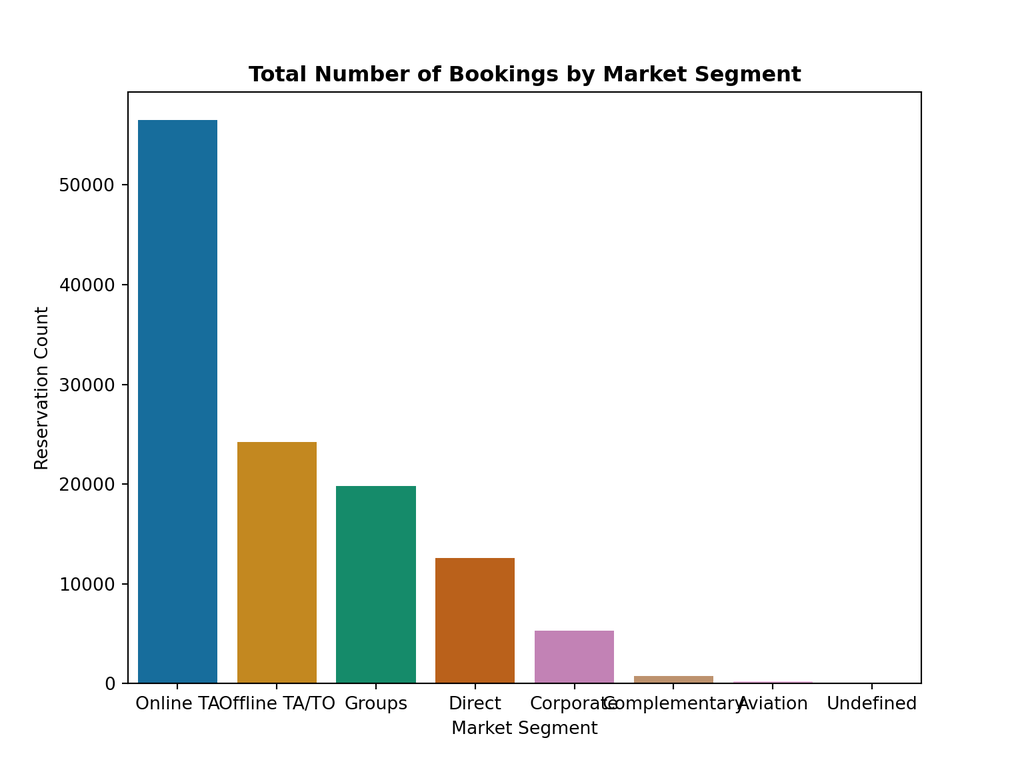

Most of the bookings are made through online travel agents and less than 20% are made directly by tourists.

```
## Transient          0.750591
## Transient-Party    0.210436
## Contract           0.034140
## Group              0.004833
## Name: customer_type, dtype: float64
```

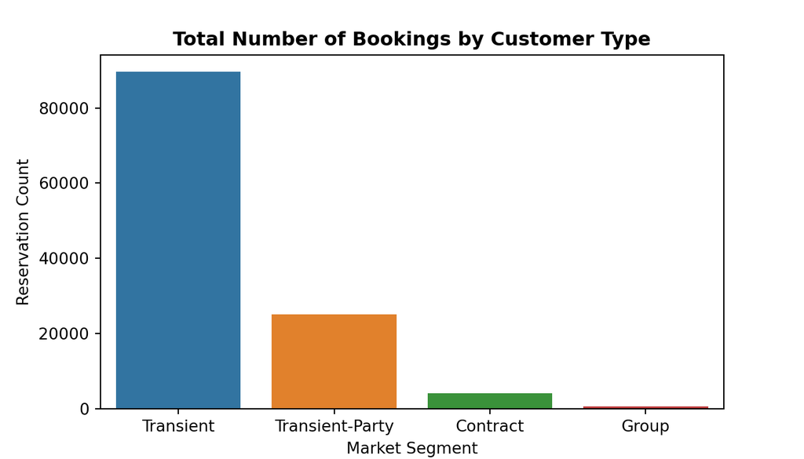

This plot depicts that 75% of the bookings are transient bookings, 21% are transient-party and almost 3% are contract bookings.

```
## 0    0.588977
## 1    0.278298
## 2    0.108627
## 3    0.020915
## 4    0.002848
## 5    0.000335
## Name: total_of_special_requests, dtype: float64
```

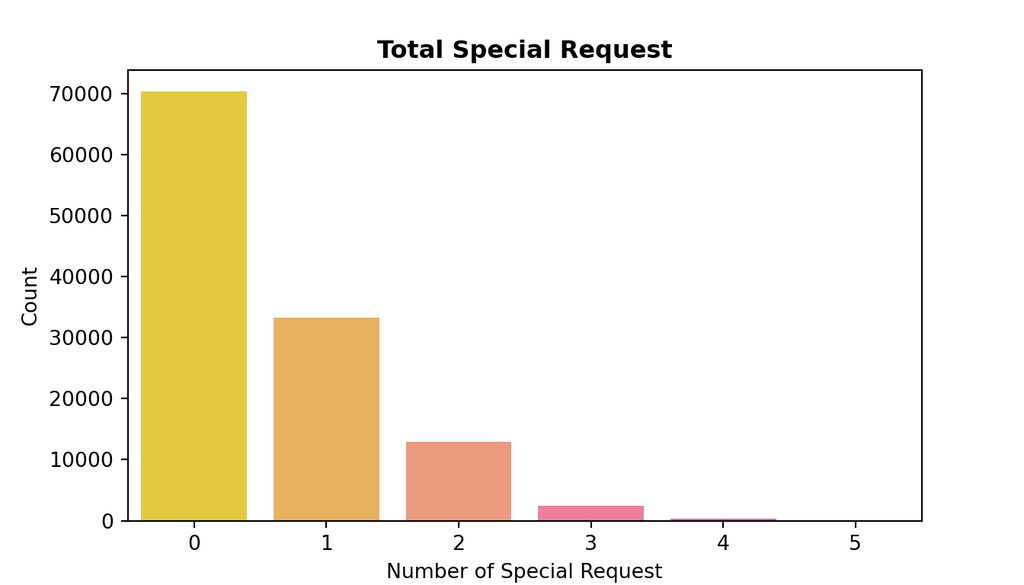

Almost 60% of the bookings come with no special requests.

```
## ([0, 1, 2, 3, 4, 5, 6, 7, 8, 9, 10, 11], <a list of 12 Text major ticklabel objects>)
```

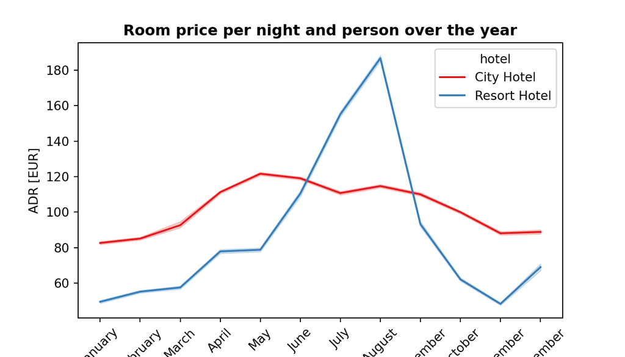

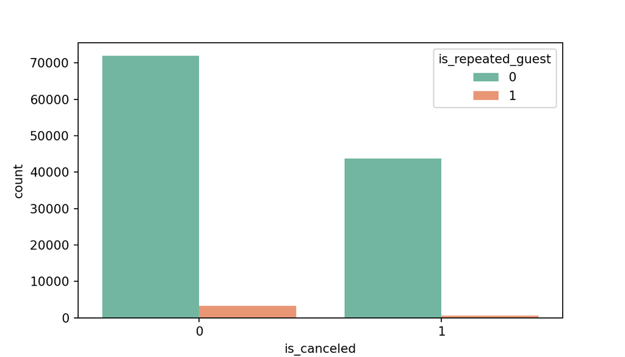

The guests who choose to book again are more likely to not cancel their bookings.

```
## No Deposit    0.876464
## Non Refund    0.122179
## Refundable    0.001357
## Name: deposit_type, dtype: float64
```

[output not shown]

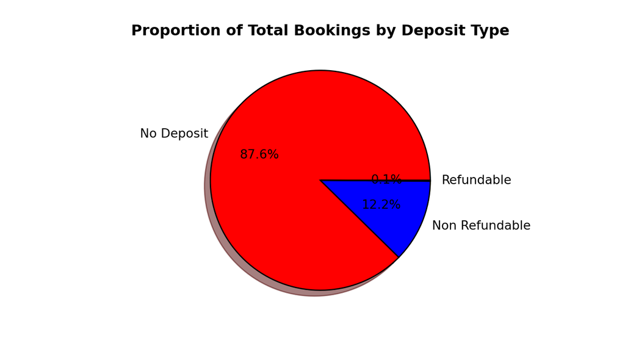

The majority of the bookings are made without deposit.

```
## deposit_type  is_canceled
## No Deposit    0              0.716230
##               1              0.283770
## Non Refund    1              0.993624
##               0              0.006376
## Refundable    0              0.777778
##               1              0.222222
## Name: is_canceled, dtype: float64
```

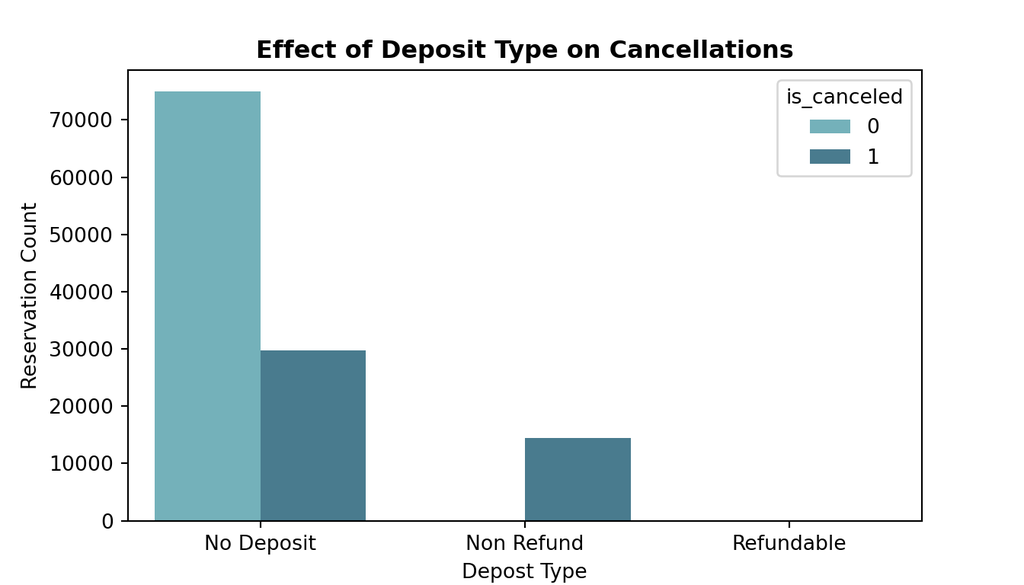

```
## meal       is_canceled
## BB         0              0.626151
##            1              0.373849
## FB         1              0.598997
##            0              0.401003
## HB         0              0.655397
##            1              0.344603
## SC         0              0.627606
##            1              0.372394
## Undefined  0              0.755346
##            1              0.244654
## Name: is_canceled, dtype: float64
```

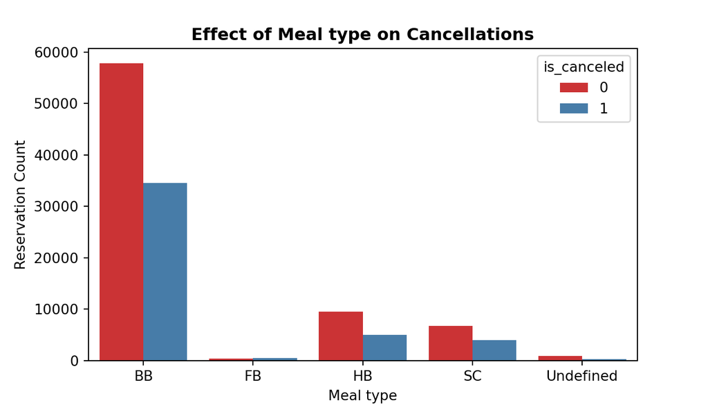

The bed&breakfast meal is the most preffered by tourists and obviously, this type has the highest number of cancellations.

```
## required_car_parking_spaces  is_canceled
## 0                            0              0.605051
##                              1              0.394949
## 1                            0              1.000000
## 2                            0              1.000000
## 3                            0              1.000000
## 8                            0              1.000000
## Name: is_canceled, dtype: float64
```

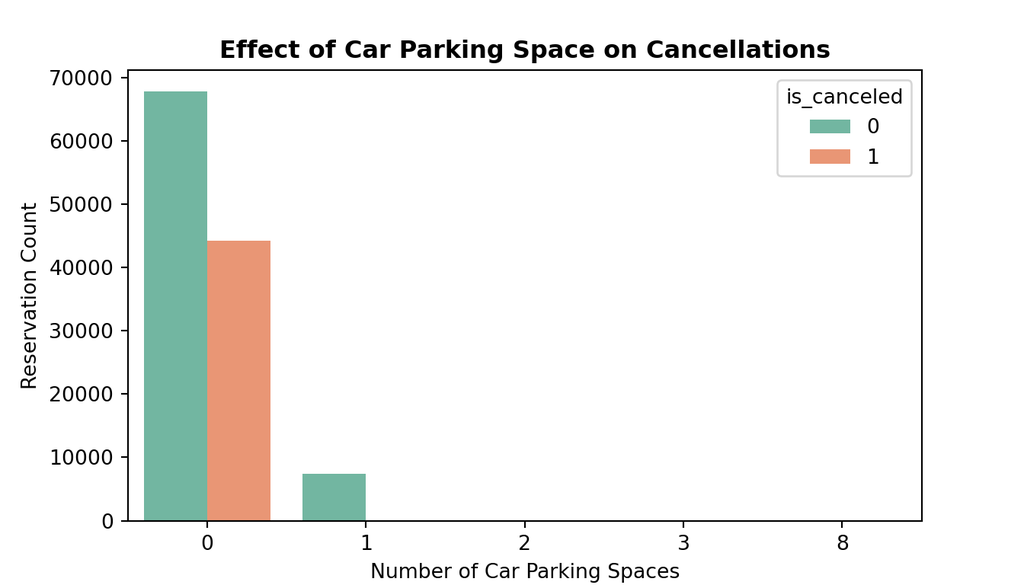

Almost 40% of the bookings were cancelled by guests who did not ask for a parking space.

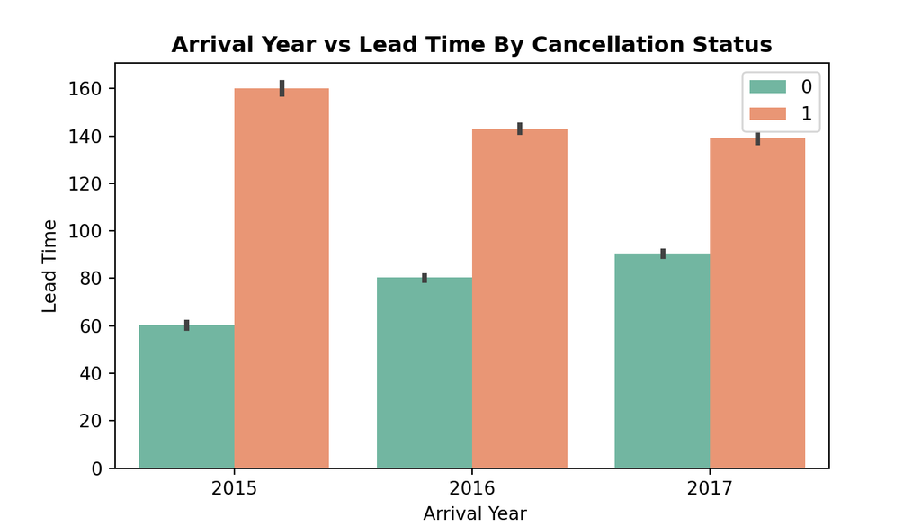

Bookings with lead time less than 100 days are less likely to be cancelled.